# Unraveling the Goal-Scoring Efficiency for Crosses between FIFA World Cups: A Comparative Analysis of FIFA World Cup™ Russia 2018 and FIFA World Cup™ Qatar 2022

Eujin Chae and Professor Lyford

2025-05-18

[figure not shown]

USA vs Iran World Cup

When it comes to football’s biggest stage, the FIFA World Cup, every detail matters because tiny margins can separate a win and a loss. Therefore, teams look to gain any competitive edge, whether it is player fitness, tactics, or nutrition. In recent years, data has been the source of margin teams strive for. The advancement of technology and increased availability of exhaustive data have enabled teams to transform data into meaningful insights that help coaches and players make smarter decisions on and off the field. Liverpool FC is a primary example of a team that has revolutionized the use of data in the world of football. Before data usage became popular in football, Liverpool employed Dr.Ian Graham, a PhD in physics from Cambridge and a football researcher at Decision Technology (MIT Sloan). Graham created a database of more than 100,000 players, which he then used to identify undervalued talents like Mohammed Salah, Allison Becker, and Virgil Van Dijk, who have all been instrumental in helping Liverpool reclaim their glory days (New York Times). This Moneyball example is certainly not a holistic representation of how data is used in football, but it exemplifies the value of data analytics in football.

## The Big Question

One day, I came across a FIFA article stating that teams in the FIFA World Cup Qatar 2022 were 8.8% more efficient at converting crosses into goals compared to those in the 2018 World Cup in Russia. As a passionate player, lifelong fan, and data enthusiast, I was immediately intrigued. Two questions immediately came to mind: Is this increase in crossing efficiency (goal-scoring crossing efficiency is defined as the percentage of attempts at goal from crosses that resulted in a goal, and attempt at goal is any shot attempt, including shots that are blocked and off target.) simply due to random variation, or are teams in 2022 genuinely more effective? And if so, what factors are driving that improvement? So, to answer these questions, we decided to use the tools we have — statistics, data science, and FIFA World Cup match event data provided by StatsBomb, a UK-based football analytics company.

So, to answer these questions I decided to use the tools I have — statistics, data science, and FIFA World Cup match event data provided by StatsBomb, a UK-based football analytics company.

## What Even is a Cross? and why should we care?

What even is a cross? Crossing is a classic attacking strategy where a player delivers the ball from wide areas of the pitch into the opponent’s 18-yard box. Think of Kevin De Bruyne’s signature whipped low ball delivered right to the forward’s feet, or if you are someone of an older generation, think of David Beckham’s infamous “Bend it like Beckham” delivery. Crossing in football holds vital importance because teams from the big five leagues (English Premier League, La Liga, Bundesliga, Ligue One, and Seria-A) cross the ball on average 18 per match (Sarkar 2018) and in major tournaments like the FIFA World cup, 25% of goals come from crosses (Pulling et al. 2018), so in modern football and at the highest level, a big bulk of goals originate from crosses. However, despite the importance of crossing, this play has not been extensively studied because, as far as we know, there are only four published studies on crosses from the FIFA World Cup. Thus, we believe the insights we present will be valuable in understanding more about crosses, and by presenting data visually, the findings of this research can be widely accessible to the football community.

## So did Goal-Scoring Crossing Efficiency really get better?

Most definitely. 20 goals were scored from 216 open-play crosses in 2018, resulting in a 9.3% goal-scoring efficiency for crosses. In contrast, 41 goals were scored from 226 open-play crosses in 2022, resulting in an increased 18.1% goal-scoring efficiency for crosses. Using a 2-sample proportion test, we found that the increase wasn’t just a random occurrence. The test yielded a p-value of 0.005108, giving us compelling evidence that teams in 2022 were indeed much more effective at converting crosses (See Appendix).

But the big question now is: Why?

## A Shift in Play patterns of Crosses

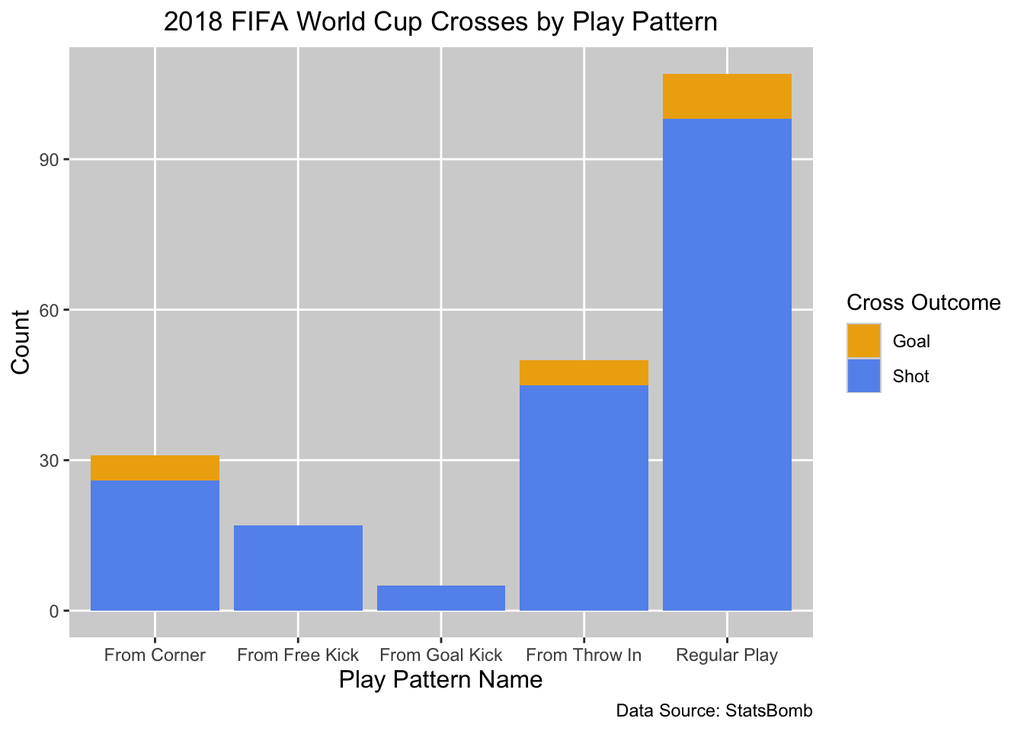

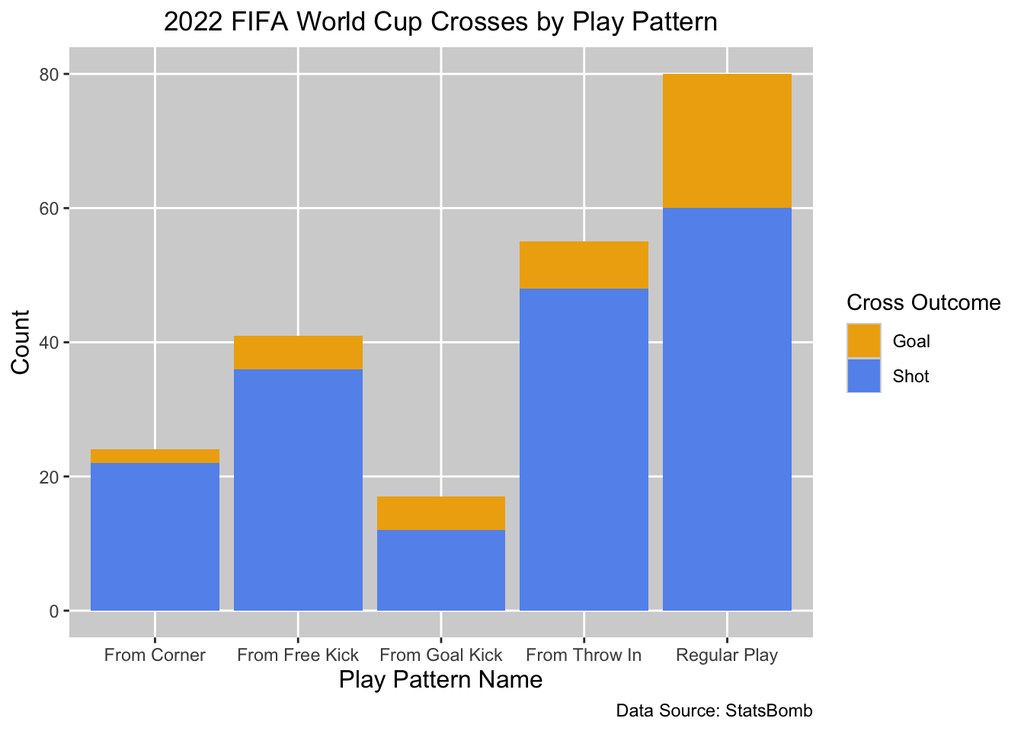

To understand why teams were more effective in 2022, we dug deeper into how teams got into crossing positions (Play Pattern). Play Pattern is defined as the passage of play relevant to the cross. For example, a goal kick play pattern cross means that the cross originated from a goal kick. We found that in 2022, teams generated significantly more crosses using goal kick and free kick play patterns. We verified the significance of this result using a Chi-Square test and by looking at its standardized residuals (See Appendix). Furthermore, 10 goals in 2022 originated from free kick and goal kick play patterns, while zero did in 2018 (See Appendix).In addition, there was a significant decrease in regular play pattern crosses; however, despite the decrease, twice as many goals were scored from regular play pattern (See Appendix).

## Playing Out from the Back

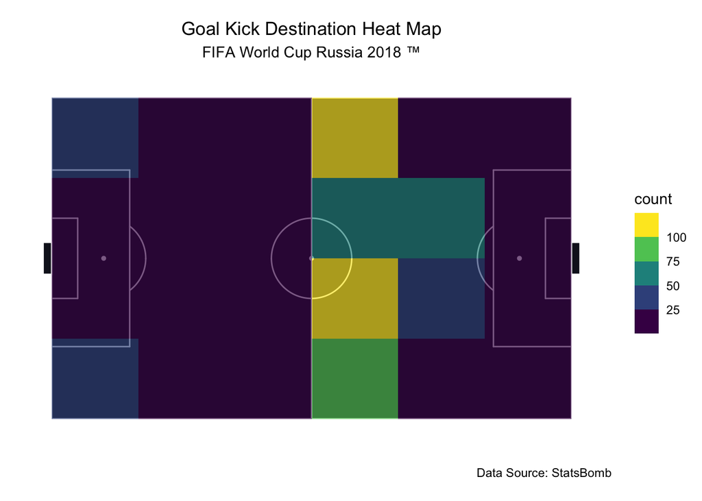

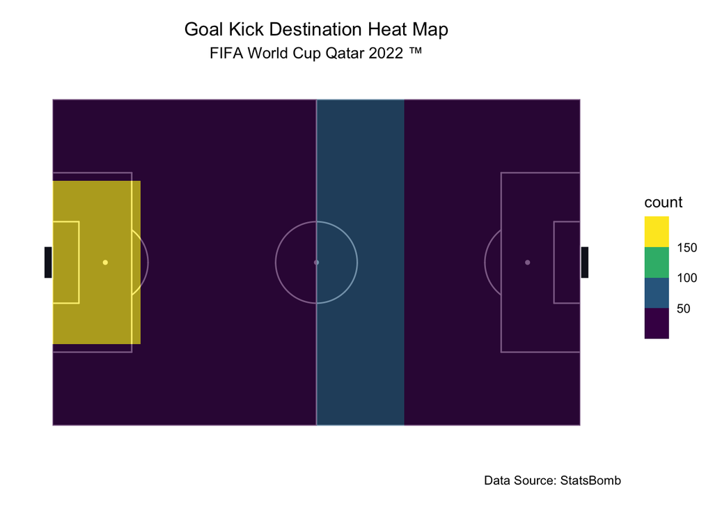

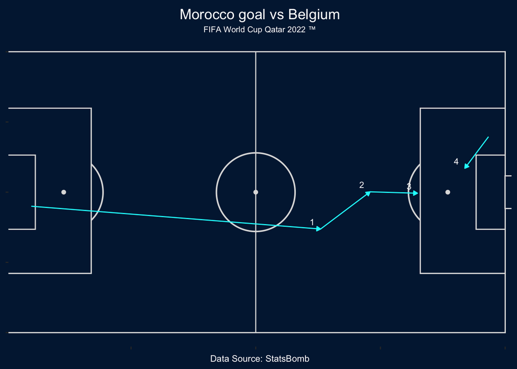

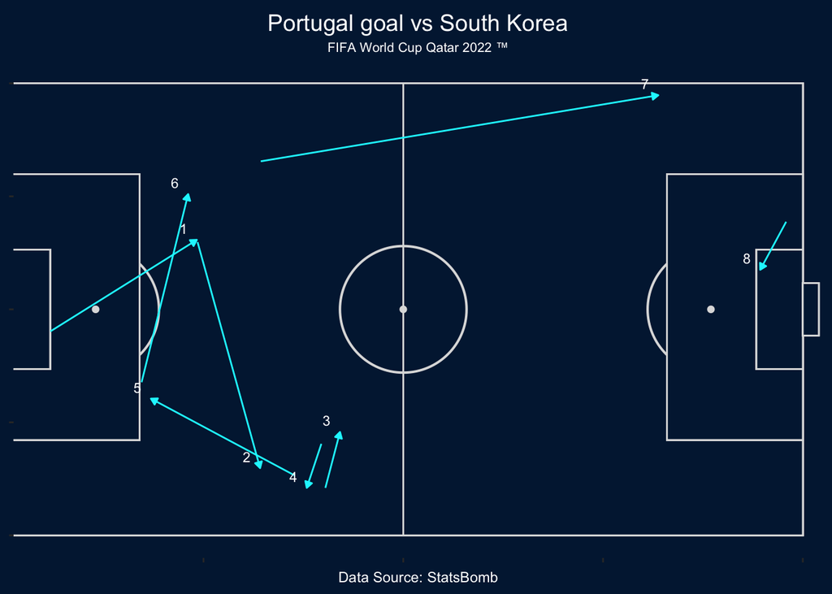

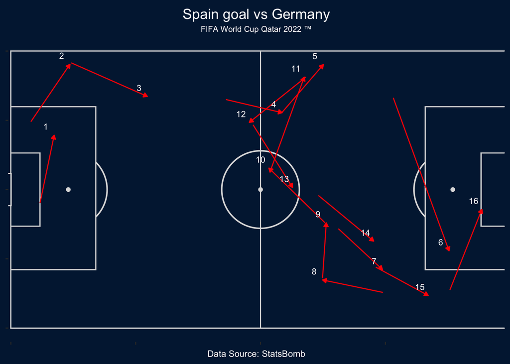

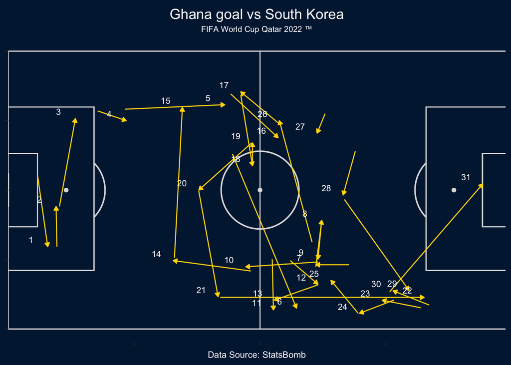

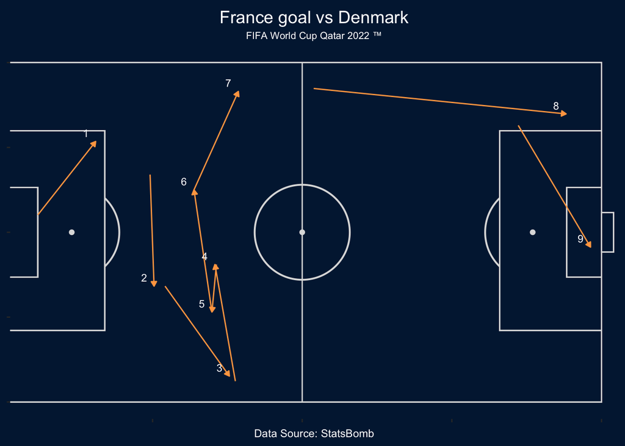

Another big trend we observed was that teams in 2022 preferred to play short goal kicks — a type of goal kick that initiates build-up play rather than long punts that lack intentionality. This phenomenon can be attributed to the new rule change in 2019, where the ball no longer needs to leave the penalty area for a player to receive the pass from a goal kick. The number of goal kicks playing out of the back increased by 25% in 2022, and the number of long goal kicks dropped by 31% in 2022 (See Appendix). Moreover, when looking at the goals that originated from the goal kick play pattern, we were able to observe that teams played short and then connected intentional passes that eventually led to dangerous crossing opportunities. This shows that teams in 2022 took advantage of the new rule change by playing more creatively and with more intention, which led teams to generate more dangerous crossing opportunities.

## Using Supervised Machine Learning Models to Predict Tournament Year

### Random Forest Predicting Tournament Year Performance

| Accuracy | Kappa |
| --- | --- |
| 0.6334416 | 0.2650244 |

### Top 10 Most Important Variables in Random Forest Model

| Variable | Overall |
| --- | --- |
| pass.length | 100.00000 |
| duration | 97.68119 |
| pass.angle | 96.04898 |
| possession | 90.73782 |
| x | 87.92786 |
| y | 83.41746 |
| y_two | 80.55634 |
| x_two | 71.88162 |
| under_pressure | 69.16452 |
| position.id | 68.23472 |

So far, we’ve found that teams in 2022 effectively utilized play patterns that were underutilized in 2018. Nevertheless, we are still left with the question: what other features of the crosses changed in 2022? Was the height of the delivery different? Were more crosses played in different locations? Did the crosser have more time in 2022? To answer these questions, we built a supervised learning classification model -to predict whether a cross came from 2018 or 2022. Suppose we can create a model that can accurately distinguish the crosses between the two tournaments. In that case, it suggests that the underlying features of the crosses have fundamentally changed.

We built and trained several supervised models such as Linear Discriminant Analysis, Random Forest, and XGBoost models to classify between 2022 and 2018 based on the following features

Table: Definitions of Predictor Variables Used in the Model

| Variable | Definition |
| --- | --- |
| pass.length | Length of the pass in yards. |
| pass.angle | The angle of the pass in radians. |
| duration | The length in seconds the event lasted. |
| possession | Indicates the current unique possession in the game. A single possession denotes a period of play in which the ball is in play and a single team is in control. |
| array[x,y] | The x and y coordinates of the event. |
| array[x_two, y_two] | The x and y coordinates of where the pass was delivered. |
| under_pressure1 | Whether the event was performed while being pressured by an opponent. |
| play_pattern.id | The ID of the play pattern. |
| position.id | Position ID of the player performing the event. |
| pass.goal_assist | Binary 1/0 indicating if the pass was an assist to a goal. |
| pass.body_part.id | ID of the body part used to make the pass. |

It is reasonable to think that crosses performed without pressure leads to better crossing conversion because if a crosser has more time and space to cross the ball, there is a good chance that it would be a good quality cross. In previous research by Pulling et al. (2018), the crossing variable, “defensive pressure,” was significantly associated with “goal-scoring attempts .” However, when we conducted a chi-square test to examine the relationship between defensive pressure and the outcome of crosses (whether it led to a goal or shot attempt), we found that the status of pressure does not significantly impact the outcome of crosses; in other words, the proportion of goals/shots made from crosses did not significantly differ between crosses that were performed under or without pressure.

Our findings show an apparent contradiction between the results from predictive modeling and statistical inference methods. Our random forest supervised learning model achieved a fair accuracy in classifying the tournament years of the crosses and identified key variables, such as pass length, pass angle, duration, possession time, location of cross, and under pressure, as important variables for classifying between tournaments. However, when these same variables were tested individually using statistical tests such as prop.test() and t.test(), most were not statistically significant.

This tension between predictive modeling and statistical inference method is consistent with the argument that is made by Breiman (2001). Breiman explains that applying simple parametric models (e.g., prop.test) to complex data can result in a misinterpretation of the true relationship of the data and emphasizes that algorithmic models such as random forest are capable of uncovering complex non-linear relationships between variables, which simple parametric models may fail to do.

Therefore, the lack of statistical significance does not invalidate the results of our model. In addition, this suggests that football research that involves highly complex data, like our data, may be best approached with algorithmic models as they have the capability of detecting complex patterns.

## Using Supervised Machine Learning to predict Goals

### Random Forest Predicting Goals Performance

| Sensitivity | Precision | Kappa |
| --- | --- | --- |
| 0.294 | 0.625 | 0.327 |

### Top 10 Most Important Variables in Random Forest Model

| Variable | Overall |
| --- | --- |
| DistToGoal | 100.00000 |
| DistSGK | 77.22123 |
| density | 75.80975 |
| density.incone | 71.72523 |
| distance.ToD2.360 | 66.59185 |
| possession | 66.48150 |
| x | 62.21960 |
| pass.angle | 62.14570 |
| pass.length | 58.29048 |
| y_two | 57.96578 |

After identifying a fundamental difference in crossing between the two tournaments and the key variables that distinguish them, we built and trained a random forest model that predicts the outcome of crosses (goal or no goal). While the previous model relied solely on crossing features, this model also incorporated a set of shot-related variables, which are shown below. However, because shot-related data was only available for the 2022 World Cup, we addressed the lack of data by combining the 2022 World Cup data with Euro 2020 and 2024 data, which is also a major football tournament. The objective of this model was to identify the most important variables in predicting whether a cross leads to a goal; therefore, when building our model, we prioritized sensitivity and precision. By focusing on sensitivity, the model aims to capture as many goals as possible. At the same time, precision ensures that when our model predicts a goal, our predictions are likely to be correct. Thus, the focus on sensitivity and precision allows us to analyze the characteristics of crosses that lead to goals reliably.

Table: Definitions of Predictor Variables Used in the Model

| Variable | Definition |
| --- | --- |
| pass.length | Length of the pass in yards. |
| pass.angle | The angle of the pass in radians. |
| duration | The length in seconds the event lasted. |
| possession | Indicates the current unique possession in the game. A single possession denotes a period of play in which the ball is in play and a single team is in control. |
| array[x,y] | The x and y coordinates of the event. |
| array[x_two, y_two] | The x and y coordinates of where the pass was delivered. |
| under_pressure1 | Whether the event was performed while being pressured by an opponent. |
| play_pattern.id | The ID of the play pattern. |
| position.id | Position ID of the player performing the event. |
| pass.goal_assist | Binary 1/0 indicating if the pass was an assist to a goal. |
| pass.body_part.id | ID of the body part used to make the pass. |
| DistToGoal | Distance from the shooter’s location to the center of the goal. |
| DistSGK | The distance between the shooter and the goalkeeper. |
| density | Density of defenders behind the ball. |
| density.incone | Density filtered for only defenders in the cone between the shooter and each goal post. |
| distance.ToD2.360 | Distance between the shooter and second closest defender. |
| distance.ToD1.360 | Distance between the shooter and closest defender. |
| DefendersBehindBall | The number of defenders behind the ball. |
| att_n_def | Number of attackers and defenders in the box. |
| att_v_def | Difference: number of attackers minus defenders. |
| attackers | Total number of attackers in the box. |

Our final model achieved a sensitivity of 29.4%, meaning the model captured 29.4% of all the goals in the testing set and a precision of 62.5%, which means that the model is correct 62.5% of the time when it predicts a goal. The performance of our model is not the best because it misses many goals, but it is crucial to note that predicting goals from crosses is challenging due to their rare occurrence and the complex nature of the game. When looking at game footage of false positive predictions, we were able to verify that many of these were crosses that nearly ended up in the back of the net. As a result, although our model is not the best, it certainly reflects important features in crosses that lead to goals.

```
##             Variable Importance_goals       Variable Importance_year
## 1         DistToGoal        100.00000    pass.length       100.00000
## 2            DistSGK         77.22123       duration        97.68119
## 3            density         75.80975     pass.angle        96.04898
## 4     density.incone         71.72523     possession        90.73782
## 5  distance.ToD2.360         66.59185              x        87.92786
## 6         possession         66.48150              y        83.41746
## 7                  x         62.21960          y_two        80.55634
## 8         pass.angle         62.14570          x_two        71.88162
## 9        pass.length         58.29048 under_pressure        69.16452
## 10             y_two         57.96578    position.id        68.23472
```

When examining the variables that were most important for predicting goals, it is notable that several variables previously identified as key to distinguishing tournament years, such as x, y_two, possession, pass.angle, and pass. length, reappeared. In addition, shot related features such as DistToGoal, DistSGK, density, density.incone, and distance.ToD2.360 were also highly influential variables. The presence of both crossing and shooting variables being influential variables for our model suggests that the outcome of a cross does not solely depend on the cross itself but is also heavily influenced by shot-related features.

In addition, the overlap in important variables across tournament year and goal prediction models implies that these variables are not only key in distinguishing between the two tournaments but also are highly influential variables in determining the outcome of crosses; therefore, this ultimately provides evidence that changes in these variables may drive the statistically significant increase in goal-scoring efficiency in crosses.

## Conclusion

In conclusion, our investigation into the goal-scoring efficiency of crosses at the FIFA World Cup reveals that teams in 2022 were significantly more effective in scoring from crosses. We verified this through our two-sample proportions test.

Furthermore, we extended our investigation by trying to understand what factors drive that improvement. Initially, we did exploratory data analysis by looking at the play pattern of crosses and trying to observe if there was a difference in how teams generated crossing opportunities. We were able to observe a tactical shift in crossing where teams in 2022 utilized underused play patterns such as goal-kicks and free-kicks to generate dangerous crossing opportunities. We found that goal-kick and free-kick play pattern crosses led to 10 goals in 2022, while zero goals were produced from these play patterns. In addition, when we compared the distribution of goal-kicks across the two tournaments, we discovered that teams in 2022 preferred to play short goal-kicks, likely due to a rule change in 2019 that enabled build-up play and intentional passes that eventually led to structured attacks involving crosses.

Through the use of supervised learning, we were able to identify “x,” “y_two,” “pass.angle,” “pass.length,” and “possession” as key crossing features distinguishing between 2022 and 2018 crosses. Interestingly, these same features reappeared as important features for our model predicting the cross outcomes; therefore, the overlap in important variables across tournament year and goal prediction models suggests that it may be differences in these variables that drive the change in goal-scoring efficiency of crosses. Due to the unavailability of shot-related variables for World Cup 2018, we couldn’t incorporate those into our model predicting tournament years, but in the future, a comparative analysis of FIFA World Cups incorporating those features may help us learn more about crosses.

## Work Cited

How Data (and Some Breathtaking Soccer) Brought Liverpool to the Cusp of Glory - the New York Times, www.nytimes.com/2019/05/22/magazine/soccer-data-liverpool.html. Accessed 18 May 2025.

“MIT Sloan Sports Analytics Conference Speaker: Ian Graham.” MIT Sloan Sports Analytics Conference, www.sloansportsconference.com/people/ian-graham. Accessed 18 May 2025.

Pulling, Craig. (PDF) Analysis of Crossing at the 2014 FIFA World Cup, www.researchgate.net/publication/327433529_Analysis_of_crossing_at_the_2014_FIFA_World_Cup. Accessed 18 May 2025.

Sarkar, Sumit. “Paradox of Crosses in Association Football (Soccer) – a Game-Theoretic Explanation.” De Gruyter Brill, De Gruyter, 1 Mar. 2018, www.degruyter.com/document/doi/10.1515/jqas-2017-0073/html.

Breiman, Leo. “Statistical Modeling: The Two Cultures (with Comments and a Rejoinder by the Author).” Project Euclid, Institute of Mathematical Statistics, projecteuclid.org/journals/statistical-science/volume-16/issue-3/Statistical-Modeling–The-Two-Cultures-with-comments-and-a/10.1214/ss/1009213726.full. Accessed 18 May 2025.

## Appendix (Statistical Test Results)

### Hypothesis Testing for goal-scoring efficiency from crosses between the tournaments

```
##
##  2-sample test for equality of proportions with continuity correction
##
## data:  c(41, 20) out of c(226, 216)
## X-squared = 6.597, df = 1, p-value = 0.005108
## alternative hypothesis: greater
## 95 percent confidence interval:
##  0.03109647 1.00000000
## sample estimates:
##     prop 1     prop 2
## 0.18141593 0.09259259
```

### Relative Frequency of Play Patterns by their respective Tournament Year, Chi-Square Test, and standardized residuals

| Relative frequency of play patterns by their respective tournament year 2018 | Relative frequency of play patterns by their respective tournament year 2022 |
| --- | --- |
| 14.76 | 11.06 |
| 8.10 | 18.89 |
| 2.38 | 7.83 |
| 23.81 | 25.35 |
| 50.95 | 36.87 |

|  | Standardized residuals of play patterns by their respective tournament year 2018 | Standardized residuals of play patterns by their respective tournament year 2022 |
| --- | --- | --- |
| From Corner | 1.1416598 | -1.1416598 |
| From Free Kick | -3.2561215 | 3.2561215 |
| From Goal Kick | -2.5483670 | 2.5483670 |
| From Throw In | -0.3685105 | 0.3685105 |
| Regular Play | 2.9330224 | -2.9330224 |

### Chi-sq test for differences in bin locations of goal kicks between the years 2018 and 2022

|  | Relative frequency of bin locations of goal kicks by their respective tournament year 2018 | Relative frequency of bin locations of goal kicks by their respective tournament year 2022 |
| --- | --- | --- |
| bin 1 | 18.40 | 44.50 |
| bin 2 | 7.56 | 11.81 |
| bin 3 | 74.04 | 43.69 |

```
##
##  Pearson's Chi-squared test
##
## data:  chisq_data_4
## X-squared = 157.57, df = 2, p-value < 2.2e-16
```

|  | Standardized residuals of bin locations by their respective tournament year 2018 | Standardized residuals of bin locations by their respective tournament year 2022 |
| --- | --- | --- |
| bin 1 | -11.188531 | 11.188531 |
| bin 2 | -2.861582 | 2.861582 |
| bin 3 | 12.394596 | -12.394596 |

### Chi-sq test for differences in defensive pressure and cross outcomes

Summary of Crosses Under Pressure by Tournament Year

| Group | Crosses Under Pressure | Total Crosses | Proportion |
| --- | --- | --- | --- |
| 2022 | 69 | 1372 | 0.050 |
| 2018 | 333 | 1323 | 0.252 |

Two-Sample Proportion Test Results

| Chi-squared | df | p-value | 95% CI (Lower) | 95% CI (Upper) |
| --- | --- | --- | --- | --- |
| 213.69 | 1 | 0 | -0.228 | -0.175 |

Chi-squared Test Results: Pressure vs Cross Outcomes

| Year | Outcome | Chi-squared | df | p-value |
| --- | --- | --- | --- | --- |
| 2022 | Shot Assist | 0.01 | 1 | 0.943 |
| 2022 | Goal Assist | 0.10 | 1 | 0.751 |
| 2018 | Shot Assist | 0.32 | 1 | 0.572 |
| 2018 | Goal Assist | 0.08 | 1 | 0.782 |

### Two Sample T-Test testing the difference in the crossing angle between the two tournaments

Welch Two Sample t-tests: Difference in Crossing Angle Between 2022 and 2018 FIFA World Cups

| Cross Type | Mean Angle (2022) | Mean Angle (2018) | t-statistic | df | p-value | 95% CI (Lower) | 95% CI (Upper) |
| --- | --- | --- | --- | --- | --- | --- | --- |
| All Shot-Assisting Crosses | 1.54 | 1.50 | 1.04 | 439.12 | 0.299 | -0.03 | 0.10 |
| Goal-Assisting Crosses | 1.48 | 1.47 | 0.15 | 39.39 | 0.878 | -0.18 | 0.21 |

### Two Sample T Test testing the difference in length of crosses between the two tournaments

Welch Two Sample t-tests: Difference in Pass Length Between 2022 and 2018 FIFA World Cups

| Cross Type | Mean Length (2022) | Mean Length (2018) | t-statistic | df | p-value | 95% CI (Lower) | 95% CI (Upper) |
| --- | --- | --- | --- | --- | --- | --- | --- |
| All Shot-Assisting Crosses | 27.47 | 28.41 | -1.00 | 421.08 | 0.318 | -2.78 | 0.91 |
| Goal-Assisting Crosses | 26.58 | 27.35 | -0.28 | 33.75 | 0.780 | -6.32 | 4.79 |